# final project

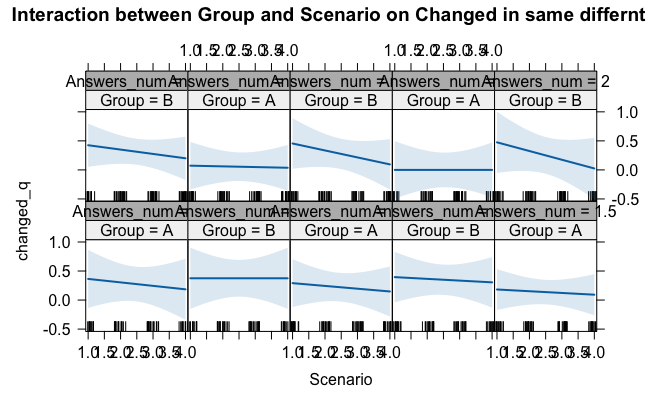

```r
effect_changed_Answers <- effect("Group*Scenario*Answers_num", model_changed_Answers)
plot(effect_changed_Answers, main = "Interaction between Group and Scenario on Changed in same differnt ")
install.packages("effects")
```

for checking the realtions with a post hoc test for LMM we use emmeans package post hoc test

```r
install.packages("emmeans") # Install emmeans if not already installed
library(emmeans)            # Load the emmeans package
```

```r
# Agree model post hoc tests
emmeans_agree <- emmeans(model_interaction, ~ Group * Scenario)
posthoc_agree <- pairs(emmeans_agree, adjust = "bonferroni")
print(posthoc_agree)
```

```
 contrast                      estimate    SE df t.ratio p.value
 A Scenario2.5 - B Scenario2.5  -0.0556 0.343 15  -0.162  0.8735

Degrees-of-freedom method: kenward-roger
```

```r
emmeans_agree_answers <- emmeans(model_agree_Answers, ~ Group * Scenario * Answers_num)
posthoc_agree_answers <- pairs(emmeans_agree_answers, adjust = "bonferroni")
print(posthoc_agree_answers)
```

```
 contrast                                                estimate    SE   df t.ratio p.value
 A Scenario2.5 Answers_num1 - B Scenario2.5 Answers_num1  -0.0556 0.343 15.0  -0.162  1.0000
 A Scenario2.5 Answers_num1 - A Scenario2.5 Answers_num2   0.9314 0.232 49.0   4.023  0.0012
 A Scenario2.5 Answers_num1 - B Scenario2.5 Answers_num2   0.8759 0.414 29.9   2.117  0.2563
 B Scenario2.5 Answers_num1 - A Scenario2.5 Answers_num2   0.9870 0.414 29.9   2.385  0.1416
 B Scenario2.5 Answers_num1 - B Scenario2.5 Answers_num2   0.9314 0.232 49.0   4.023  0.0012
 A Scenario2.5 Answers_num2 - B Scenario2.5 Answers_num2  -0.0556 0.343 15.0  -0.162  1.0000

Degrees-of-freedom method: kenward-roger
P value adjustment: bonferroni method for 6 tests
```

```r
# Credible model post hoc tests
emmeans_credible <- emmeans(model_credible, ~ Group * Scenario)
posthoc_credible <- pairs(emmeans_credible, adjust = "bonferroni")
print(posthoc_credible)
```

```
 contrast                      estimate    SE df t.ratio p.value
 A Scenario2.5 - B Scenario2.5   -0.361 0.352 15  -1.025  0.3217

Degrees-of-freedom method: kenward-roger
```

```r
emmeans_credible_answers <- emmeans(model_credible_Answers, ~ Group * Scenario * Answers_num)
posthoc_credible_answers <- pairs(emmeans_credible_answers, adjust = "bonferroni")
print(posthoc_credible_answers)
```

```
 contrast                                                estimate    SE   df t.ratio p.value
 A Scenario2.5 Answers_num1 - B Scenario2.5 Answers_num1   -0.574 0.440 32.3  -1.303  1.0000
 A Scenario2.5 Answers_num1 - A Scenario2.5 Answers_num2    0.311 0.368 45.1   0.844  1.0000
 A Scenario2.5 Answers_num1 - B Scenario2.5 Answers_num2    0.176 0.440 32.3   0.401  1.0000
 B Scenario2.5 Answers_num1 - A Scenario2.5 Answers_num2    0.884 0.440 32.3   2.008  0.3180
 B Scenario2.5 Answers_num1 - B Scenario2.5 Answers_num2    0.750 0.390 45.1   1.924  0.3640
 A Scenario2.5 Answers_num2 - B Scenario2.5 Answers_num2   -0.134 0.440 32.3  -0.305  1.0000

Degrees-of-freedom method: kenward-roger
P value adjustment: bonferroni method for 6 tests
```

```r
# Confidence model post hoc tests
emmeans_confidence <- emmeans(model_confidence, ~ Group * Scenario)
posthoc_confidence <- pairs(emmeans_confidence, adjust = "bonferroni")
print(posthoc_confidence)
```

```
 contrast                      estimate    SE df t.ratio p.value
 A Scenario2.5 - B Scenario2.5    0.462 0.337 15   1.370  0.1907

Degrees-of-freedom method: kenward-roger
```

```r
emmeans_confidence_answers <- emmeans(model_confidence_Answers, ~ Group * Scenario * Answers_num)
posthoc_confidence_answers <- pairs(emmeans_confidence_answers, adjust = "bonferroni")
print(posthoc_confidence_answers)
```

```
 contrast                                                estimate    SE   df t.ratio p.value
 A Scenario2.5 Answers_num1 - B Scenario2.5 Answers_num1   0.5249 0.378 22.7   1.387  1.0000
 A Scenario2.5 Answers_num1 - A Scenario2.5 Answers_num2   0.0598 0.238 45.0   0.251  1.0000
 A Scenario2.5 Answers_num1 - B Scenario2.5 Answers_num2   0.4624 0.378 22.7   1.222  1.0000
 B Scenario2.5 Answers_num1 - A Scenario2.5 Answers_num2  -0.4652 0.378 22.7  -1.229  1.0000
 B Scenario2.5 Answers_num1 - B Scenario2.5 Answers_num2  -0.0625 0.252 45.0  -0.248  1.0000
 A Scenario2.5 Answers_num2 - B Scenario2.5 Answers_num2   0.4027 0.378 22.7   1.064  1.0000

Degrees-of-freedom method: kenward-roger
P value adjustment: bonferroni method for 6 tests
```

```r
# Changing model post hoc tests
emmeans_changing <- emmeans(model_changing, ~ Group * Scenario)
posthoc_changing <- pairs(emmeans_changing, adjust = "bonferroni")
print(posthoc_changing)
```

```
 contrast                      estimate    SE df t.ratio p.value
 A Scenario2.5 - B Scenario2.5   -0.181 0.225 15  -0.802  0.4352

Degrees-of-freedom method: kenward-roger
```

```r
emmeans_changing_answers <- emmeans(model_changing_Answers, ~ Group * Scenario * Answers_num)
posthoc_changing_answers <- pairs(emmeans_changing_answers, adjust = "bonferroni")
print(posthoc_changing_answers)
```

```
 contrast                                                estimate    SE   df t.ratio p.value
 A Scenario2.5 Answers_num1 - B Scenario2.5 Answers_num1   -0.049 0.310 42.1  -0.158  1.0000
 A Scenario2.5 Answers_num1 - A Scenario2.5 Answers_num2    0.625 0.298 45.3   2.096  0.2505
 A Scenario2.5 Answers_num1 - B Scenario2.5 Answers_num2    0.326 0.310 42.1   1.052  1.0000
 B Scenario2.5 Answers_num1 - A Scenario2.5 Answers_num2    0.674 0.310 42.1   2.175  0.2118
 B Scenario2.5 Answers_num1 - B Scenario2.5 Answers_num2    0.375 0.316 45.3   1.187  1.0000
 A Scenario2.5 Answers_num2 - B Scenario2.5 Answers_num2   -0.299 0.310 42.1  -0.965  1.0000

Degrees-of-freedom method: kenward-roger
P value adjustment: bonferroni method for 6 tests
```

```r
# Changing model post hoc tests
emmeans_changed <- emmeans(model_changed_Answers, ~ Group * Scenario)
```

```
NOTE: Results may be misleading due to involvement in interactions
```

```r
posthoc_changed <- pairs(emmeans_changed, adjust = "bonferroni")
print(posthoc_changing)
```

```
 contrast                      estimate    SE df t.ratio p.value
 A Scenario2.5 - B Scenario2.5   -0.181 0.225 15  -0.802  0.4352

Degrees-of-freedom method: kenward-roger
```

```r
emmeans_changed_answers <- emmeans(model_changed_Answers, ~ Group * Scenario * Answers_num)
posthoc_changed_answers <- pairs(emmeans_changed_answers, adjust = "bonferroni")
print(posthoc_changed_answers)
```

```
 contrast                                                estimate    SE   df t.ratio p.value
 A Scenario2.5 Answers_num1 - B Scenario2.5 Answers_num1  -0.1005 0.217 42.9  -0.464  1.0000
 A Scenario2.5 Answers_num1 - A Scenario2.5 Answers_num2   0.2745 0.210 45.3   1.305  1.0000
 A Scenario2.5 Answers_num1 - B Scenario2.5 Answers_num2   0.0245 0.217 42.9   0.113  1.0000
 B Scenario2.5 Answers_num1 - A Scenario2.5 Answers_num2   0.3750 0.217 42.9   1.731  0.5443
 B Scenario2.5 Answers_num1 - B Scenario2.5 Answers_num2   0.1250 0.223 45.3   0.561  1.0000
 A Scenario2.5 Answers_num2 - B Scenario2.5 Answers_num2  -0.2500 0.217 42.9  -1.154  1.0000

Degrees-of-freedom method: kenward-roger
P value adjustment: bonferroni method for 6 tests
```

Group A vs. Group B (Overall Scenario 2.5): First Table: The difference (estimate) between Group A and Group B for Scenario 2.5 is very small (-0.056) and not statistically significant (p.value = 0.8735). Across all scenarios, the differences between groups are minor and consistently non-significant (p > 0.05). Interaction with Answers_num (Same/Different): The interaction effect considers whether the response type (Same = 1 or Different = 2) influences the differences between groups: Some contrasts, like A Scenario2.5 Answers_num1 vs. A Scenario2.5 Answers_num2, show larger differences (e.g., estimate = 0.931 with p = 0.0012 in the first table), indicating a significant interaction effect. However, most other contrasts involving both groups and answer types have non-significant results (p > 0.05), suggesting these differences are not robust. Bonferroni Adjustment: Multiple comparisons were corrected with Bonferroni, making it harder to detect significance. Even with significant raw results, the adjusted p-values often exceed 0.05. Consistency Across Models: Differences between groups (A vs. B) and within groups based on answers (Same/Different) are generally small and not statistically meaningful. Significant contrasts, where present, are specific to certain scenarios or interactions (e.g., Same vs. Different within Group A).

plotting the responses: used chatgpt cause i dunno how to plot this (has to modify)

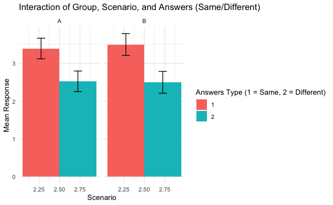

```r
# Load necessary library
library(ggplot2)

# Extract the marginal means for Group, Scenario, and Answers_num
emmeans_results <- as.data.frame(emmeans(model_interaction_Answers, ~ Group * Scenario * Answers_num))

# Create a plot
ggplot(emmeans_results, aes(x = Scenario, y = emmean, fill = as.factor(Answers_num))) +
  geom_bar(stat = "identity", position = "dodge") +  # Bar plot with dodged bars for different Answers_num
  geom_errorbar(aes(ymin = emmean - SE, ymax = emmean + SE),
                width = 0.2, position = position_dodge(0.9)) +  # Add error bars
  facet_wrap(~ Group) +  # Separate plots for each group
  labs(
    title = "Interaction of Group, Scenario, and Answers (Same/Different)",
    x = "Scenario",
    y = "Mean Response",
    fill = "Answers Type (1 = Same, 2 = Different)"
  ) +
  theme_minimal()
```

```r
NA
NA
NA
```

we can see the relation of our participant demographic with our results (their perception )

```r
library(readxl)
data2 <- read_excel("~/Downloads/Pre-study survey (Responses).xlsx")
head(data2)
```

| participant | What is your age? | What is your gender identity? | What is you highest educational level? | What is your employement status? | Please specify your occupation | Please specify your area of study |
| --- | --- | --- | --- | --- | --- | --- |
| 1 | 18-24 | Female | Doctoral degree or higher | Student | Student in clinical psychology | Ph.D clinical psychology |
| 2 | 25-34 | Female | Master's degree | Unemployed | NA | Geography- Urban and regional development management |
| 3 | 18-24 | Male | Bachelor's degree | Employed full-time | Software developper | Computer Science |
| 4 | 25-34 | Male | Some college or university | Student | university student | education |
| 5 | 35-44 | Male | Doctoral degree or higher | Employed full-time | Data Scientist | Computer Science |
| 6 | 55-64 | Female | Bachelor's degree | Employed full-time | Enseignante | Enseignement |

```r
colnames(data2)
```

```
[1] "participant"                            "What is your age?"                      "What is your gender identity?"
[4] "What is you highest educational level?" "What is your employement status?"       "Please specify your occupation"
[7] "Please specify your area of study"
```

```r
head(data)
```

| Name | ...2 | Participant_ID | Group | Scenario | Answers | Agree | Credible | Confidence | Changing | changed_q | Answers_num | predict_agree | predict_credible | predict_confidence | predict_changing | predict_changed | predict_agree_Answers | predict_credible_Answers | predict_confidence_Answers | predict_changing_Answers | predict_changed_Answers |
| --- | --- | --- | --- | --- | --- | --- | --- | --- | --- | --- | --- | --- | --- | --- | --- | --- | --- | --- | --- | --- | --- |
| Frédérique Delisle | scenario1 | 1 | A | 1 | Same answers | 1 | 2 | 5 | 1 | 0 | 1 | 3.20915 | 3.135948 | 4.129085 | 1.720915 | 0.2183007 | 3.658433 | 3.386811 | 4.132425 | 1.961757 | 0.2183007 |
| Melika | scenario1 | 2 | A | 1 | Same answers | 4 | 2 | 4 | 1 | 1 | 1 | 3.20915 | 3.135948 | 4.129085 | 1.720915 | 0.2183007 | 3.658433 | 3.386811 | 4.132425 | 1.961757 | 0.2183007 |
| Félix | scenario1 | 3 | A | 1 | Same answers | 1 | 1 | 5 | 2 | 0 | 1 | 3.20915 | 3.135948 | 4.129085 | 1.720915 | 0.2183007 | 3.658433 | 3.386811 | 4.132425 | 1.961757 | 0.2183007 |
| Vincent L. | scenario1 | 4 | A | 1 | Different answers | 4 | 4 | 5 | 1 | 0 | 2 | 3.20915 | 3.135948 | 4.129085 | 1.720915 | 0.2183007 | 2.726993 | 2.866728 | 4.125500 | 1.462450 | 0.2183007 |
| Sam Erbati | scenario1 | 5 | A | 1 | Different answers | 3 | 3 | 4 | 1 | 0 | 2 | 3.20915 | 3.135948 | 4.129085 | 1.720915 | 0.2183007 | 2.726993 | 2.866728 | 4.125500 | 1.462450 | 0.2183007 |
| Julie Duclos | scenario1 | 6 | A | 1 | Different answers | 5 | 5 | 5 | 2 | 0 | 2 | 3.20915 | 3.135948 | 4.129085 | 1.720915 | 0.2183007 | 2.726993 | 2.866728 | 4.125500 | 1.462450 | 0.2183007 |

merging two dataset :

```r
data_merged <- merge(data, data2, by.x = "Participant_ID", by.y = "participant", all.x = TRUE)

# Check the merged dataset
head(data_merged)
```

|  | Participant_ID | Name | ...2 | Group | Scenario | Answers | Agree | Credible | Confidence | Changing | changed_q | Answers_num | predict_agree | predict_credible | predict_confidence | predict_changing | predict_changed | predict_agree_Answers | predict_credible_Answers | predict_confidence_Answers | predict_changing_Answers | predict_changed_Answers | What is your age? | What is your gender identity? | What is you highest educational level? | What is your employement status? | Please specify your occupation | Please specify your area of study |
| --- | --- | --- | --- | --- | --- | --- | --- | --- | --- | --- | --- | --- | --- | --- | --- | --- | --- | --- | --- | --- | --- | --- | --- | --- | --- | --- | --- | --- |
| 1 | 1 | Frédérique Delisle | scenario1 | A | 1 | Same answers | 1 | 2 | 5 | 1 | 0 | 1 | 3.209150 | 3.135948 | 4.129085 | 1.720915 | 0.21830065 | 3.658433 | 3.386811 | 4.132425 | 1.961757 | 0.21830065 | 18-24 | Female | Doctoral degree or higher | Student | Student in clinical psychology | Ph.D clinical psychology |
| 2 | 1 | Frédérique Delisle | scenario2 | A | 2 | Same answers | 5 | 5 | 5 | 1 | 0 | 1 | 3.032680 | 2.971242 | 4.246732 | 1.703268 | 0.16535948 | 3.492921 | 3.228224 | 4.250154 | 1.949985 | 0.16535948 | 18-24 | Female | Doctoral degree or higher | Student | Student in clinical psychology | Ph.D clinical psychology |
| 3 | 1 | Frédérique Delisle | scenario3 | A | 3 | Different answers | 1 | 4 | 5 | 1 | 0 | 2 | 2.856209 | 2.806536 | 4.364379 | 1.685621 | 0.11241830 | 2.395968 | 2.549554 | 4.360957 | 1.438904 | 0.11241830 | 18-24 | Female | Doctoral degree or higher | Student | Student in clinical psychology | Ph.D clinical psychology |
| 4 | 1 | Frédérique Delisle | scenario4 | A | 4 | Different answers | 2 | 4 | 5 | 1 | 0 | 2 | 2.679739 | 2.641830 | 4.482026 | 1.667974 | 0.05947712 | 2.230456 | 2.390966 | 4.478686 | 1.427131 | 0.05947712 | 18-24 | Female | Doctoral degree or higher | Student | Student in clinical psychology | Ph.D clinical psychology |
| 5 | 2 | Melika | scenario1 | A | 1 | Same answers | 4 | 2 | 4 | 1 | 1 | 1 | 3.209150 | 3.135948 | 4.129085 | 1.720915 | 0.21830065 | 3.658433 | 3.386811 | 4.132425 | 1.961757 | 0.21830065 | 25-34 | Female | Master's degree | Unemployed | NA | Geography- Urban and regional development management |
| 6 | 2 | Melika | scenario2 | A | 2 | Different answers | 2 | 2 | 4 | 1 | 0 | 2 | 3.032680 | 2.971242 | 4.246732 | 1.703268 | 0.16535948 | 2.561480 | 2.708141 | 4.243229 | 1.450677 | 0.16535948 | 25-34 | Female | Master's degree | Unemployed | NA | Geography- Urban and regional development management |

```r
colnames(data_merged)
```

```
 [1] "Participant_ID"                         "Name"                                   "...2"
 [4] "Group"                                  "Scenario"                               "Answers"
 [7] "Agree"                                  "Credible"                               "Confidence"
[10] "Changing"                               "changed_q"                              "Answers_num"
[13] "predict_agree"                          "predict_credible"                       "predict_confidence"
[16] "predict_changing"                       "predict_changed"                        "predict_agree_Answers"
[19] "predict_credible_Answers"               "predict_confidence_Answers"             "predict_changing_Answers"
[22] "predict_changed_Answers"                "What is your age?"                      "What is your gender identity?"
[25] "What is you highest educational level?" "What is your employement status?"       "Please specify your occupation"
[28] "Please specify your area of study"
```

```r
# Load dplyr package
library(dplyr)

# Rename specific columns
data_merged <- data_merged %>%
  rename(
    Age = "What is your age?",
    gender = "What is your gender identity?",
    Education_Level = "What is you highest educational level?",
    employement = "What is your employement status?"
  )

head(data_merged)
```

|  | Participant_ID | Name | ...2 | Group | Scenario | Answers | Agree | Credible | Confidence | Changing | changed_q | Answers_num | predict_agree | predict_credible | predict_confidence | predict_changing | predict_changed | predict_agree_Answers | predict_credible_Answers | predict_confidence_Answers | predict_changing_Answers | predict_changed_Answers | Age | gender | Education_Level | employement | Please specify your occupation | Please specify your area of study |
| --- | --- | --- | --- | --- | --- | --- | --- | --- | --- | --- | --- | --- | --- | --- | --- | --- | --- | --- | --- | --- | --- | --- | --- | --- | --- | --- | --- | --- |
| 1 | 1 | Frédérique Delisle | scenario1 | A | 1 | Same answers | 1 | 2 | 5 | 1 | 0 | 1 | 3.209150 | 3.135948 | 4.129085 | 1.720915 | 0.21830065 | 3.658433 | 3.386811 | 4.132425 | 1.961757 | 0.21830065 | 18-24 | Female | Doctoral degree or higher | Student | Student in clinical psychology | Ph.D clinical psychology |
| 2 | 1 | Frédérique Delisle | scenario2 | A | 2 | Same answers | 5 | 5 | 5 | 1 | 0 | 1 | 3.032680 | 2.971242 | 4.246732 | 1.703268 | 0.16535948 | 3.492921 | 3.228224 | 4.250154 | 1.949985 | 0.16535948 | 18-24 | Female | Doctoral degree or higher | Student | Student in clinical psychology | Ph.D clinical psychology |
| 3 | 1 | Frédérique Delisle | scenario3 | A | 3 | Different answers | 1 | 4 | 5 | 1 | 0 | 2 | 2.856209 | 2.806536 | 4.364379 | 1.685621 | 0.11241830 | 2.395968 | 2.549554 | 4.360957 | 1.438904 | 0.11241830 | 18-24 | Female | Doctoral degree or higher | Student | Student in clinical psychology | Ph.D clinical psychology |
| 4 | 1 | Frédérique Delisle | scenario4 | A | 4 | Different answers | 2 | 4 | 5 | 1 | 0 | 2 | 2.679739 | 2.641830 | 4.482026 | 1.667974 | 0.05947712 | 2.230456 | 2.390966 | 4.478686 | 1.427131 | 0.05947712 | 18-24 | Female | Doctoral degree or higher | Student | Student in clinical psychology | Ph.D clinical psychology |
| 5 | 2 | Melika | scenario1 | A | 1 | Same answers | 4 | 2 | 4 | 1 | 1 | 1 | 3.209150 | 3.135948 | 4.129085 | 1.720915 | 0.21830065 | 3.658433 | 3.386811 | 4.132425 | 1.961757 | 0.21830065 | 25-34 | Female | Master's degree | Unemployed | NA | Geography- Urban and regional development management |
| 6 | 2 | Melika | scenario2 | A | 2 | Different answers | 2 | 2 | 4 | 1 | 0 | 2 | 3.032680 | 2.971242 | 4.246732 | 1.703268 | 0.16535948 | 2.561480 | 2.708141 | 4.243229 | 1.450677 | 0.16535948 | 25-34 | Female | Master's degree | Unemployed | NA | Geography- Urban and regional development management |

```r
colnames(data_merged)
```

```
 [1] "Participant_ID"                    "Name"                              "...2"                              "Group"
 [5] "Scenario"                          "Answers"                           "Agree"                             "Credible"
 [9] "Confidence"                        "Changing"                          "changed_q"                         "Answers_num"
[13] "predict_agree"                     "predict_credible"                  "predict_confidence"                "predict_changing"
[17] "predict_changed"                   "predict_agree_Answers"             "predict_credible_Answers"          "predict_confidence_Answers"
[21] "predict_changing_Answers"          "predict_changed_Answers"           "Age"                               "gender"
[25] "Education_Level"                   "employement"                       "Please specify your occupation"    "Please specify your area of study"
```

```r
# Convert categorical variables to factors
data_merged$Education_Level <- factor(data_merged$Education_Level,
                                      levels = c("Doctoral degree or higher", "Master's degree", "Bachelor's degree"))

data_merged$Age <- factor(data_merged$Age,
                          levels = c("18-24", "25-34", "35-44", "45-54", "55-64"))

data_merged$Gender <- factor(data_merged$gender,
                             levels = c("Male", "Non-binary/non-conforming", "Female"))

data_merged$Occupation <- factor(data_merged$employement,
                                 levels = c("Student", "Unemployed", "Employed full-time", "Female"))
```

```r
install.packages("gridExtra")
```

plotting the distribution :

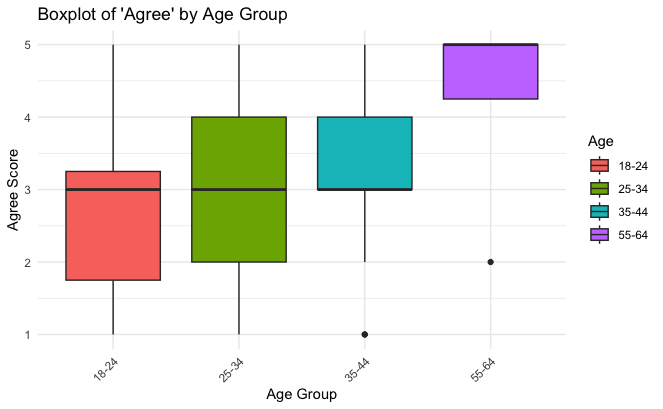

```r
ggplot(data_merged, aes(x = Age, y = Agree, fill = Age)) +
  geom_boxplot() +
  labs(title = "Boxplot of 'Agree' by Age Group", x = "Age Group", y = "Agree Score") +
  theme_minimal() +
  theme(axis.text.x = element_text(angle = 45, hjust = 1))
```

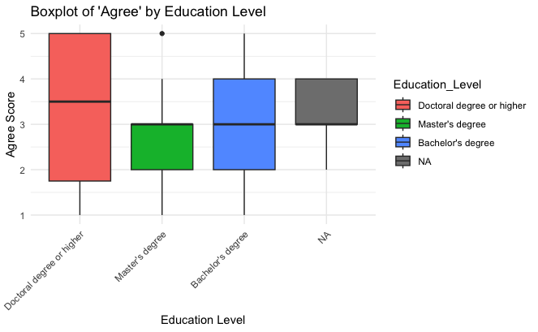

```r
ggplot(data_merged, aes(x = Education_Level, y = Agree, fill = Education_Level)) +
  geom_boxplot() +
  labs(title = "Boxplot of 'Agree' by Education Level", x = "Education Level", y = "Agree Score") +
  theme_minimal() +
  theme(axis.text.x = element_text(angle = 45, hjust = 1))
```

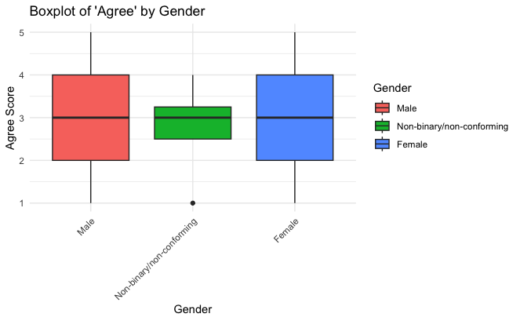

```r
ggplot(data_merged, aes(x = Gender, y = Agree, fill = Gender)) +
  geom_boxplot() +
  labs(title = "Boxplot of 'Agree' by Gender", x = "Gender", y = "Agree Score") +
  theme_minimal() +
  theme(axis.text.x = element_text(angle = 45, hjust = 1))
```

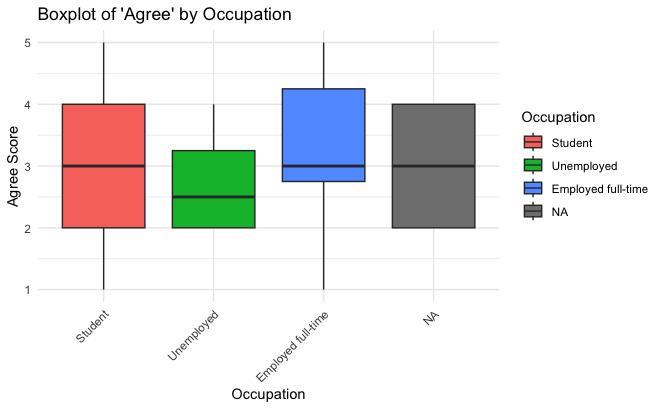

```r
ggplot(data_merged, aes(x = Occupation, y = Agree, fill = Occupation)) +
  geom_boxplot() +
  labs(title = "Boxplot of 'Agree' by Occupation", x = "Occupation", y = "Agree Score") +
  theme_minimal() +
  theme(axis.text.x = element_text(angle = 45, hjust = 1))
```

fitting the LMM :

```r
library(lme4)

# Linear Mixed Model with Age, Education Level, Gender, and Occupation as covariates
model_agree <- lmer(Agree ~ Group + Scenario + Age + Education_Level + gender + employement + (1 | Participant_ID), data = data_merged)

# Display model summary
summary(model_agree)
```

```
Linear mixed model fit by REML. t-tests use Satterthwaite's method ['lmerModLmerTest']
Formula: Agree ~ Group + Scenario + Age + Education_Level + gender + employement +      (1 | Participant_ID)
   Data: data_merged

REML criterion at convergence: 173.7

Scaled residuals:
    Min      1Q  Median      3Q     Max
-2.1260 -0.6855  0.1166  0.6243  2.2328

Random effects:
 Groups         Name        Variance Std.Dev.
 Participant_ID (Intercept) 0.2434   0.4933
 Residual                   1.2929   1.1370
Number of obs: 60, groups:  Participant_ID, 15

Fixed effects:
                                 Estimate Std. Error      df t value Pr(>|t|)
(Intercept)                        3.0361     0.9591  3.8442   3.166   0.0359 *
GroupB                             1.2972     0.8359  3.0000   1.552   0.2185
Scenario                          -0.1467     0.1313 44.0000  -1.117   0.2700
Age25-34                           1.2102     0.8409  3.0000   1.439   0.2457
Age35-44                           1.6611     0.9910  3.0000   1.676   0.1923
Age55-64                           2.2546     1.0889  3.0000   2.071   0.1302
Education_LevelMaster's degree    -1.2620     0.7624  3.0000  -1.655   0.1964
Education_LevelBachelor's degree  -0.6741     0.8595  3.0000  -0.784   0.4901
genderMale                        -0.3222     0.7272  3.0000  -0.443   0.6877
genderNon-binary/non-conforming   -1.5750     1.4865  3.0000  -1.060   0.3671
employementEmployed part-time     -1.2611     1.2892  3.0000  -0.978   0.4001
employementStudent                -0.1778     0.7272  3.0000  -0.244   0.8226
employementUnemployed              0.1324     1.1004  3.0000   0.120   0.9118
---
Signif. codes:  0 ‘***’ 0.001 ‘**’ 0.01 ‘*’ 0.05 ‘.’ 0.1 ‘ ’ 1
```

```
Correlation matrix not shown by default, as p = 13 > 12.
Use print(x, correlation=TRUE)  or
    vcov(x)        if you need it
```

Group: Group B participants show a positive difference, but it is not statistically significant.

Other factors such as Gender and Employment do not have significant effects on Agree scores, as indicated by their t-values.

```r
# Linear Mixed Model with Age, Education Level, Gender, and Occupation as covariates
model_Credible <- lm(Credible ~ Group + Scenario + Age + Education_Level + gender + employement, data = data_merged)

# Display model summary
summary(model_Credible)
```

```
Call:
lm(formula = Credible ~ Group + Scenario + Age + Education_Level +
    gender + employement, data = data_merged)

Residuals:
    Min      1Q  Median      3Q     Max
-2.0400 -0.7260  0.1286  0.6987  1.8950

Coefficients:
                                 Estimate Std. Error t value Pr(>|t|)
(Intercept)                        3.7417     0.7644   4.895  1.2e-05 ***
GroupB                             0.6583     0.6386   1.031  0.30789
Scenario                          -0.1400     0.1328  -1.054  0.29719
Age25-34                           0.2194     0.6425   0.342  0.73420
Age35-44                           0.2167     0.7571   0.286  0.77600
Age55-64                           2.2361     0.8319   2.688  0.00991 **
Education_LevelMaster's degree    -1.1139     0.5825  -1.912  0.06194 .
Education_LevelBachelor's degree  -1.3778     0.6566  -2.098  0.04128 *
genderMale                        -0.4333     0.5556  -0.780  0.43931
genderNon-binary/non-conforming   -0.3250     1.1357  -0.286  0.77600
employementEmployed part-time      0.4333     0.9849   0.440  0.66197
employementStudent                 0.4333     0.5556   0.780  0.43931
employementUnemployed             -0.4972     0.8407  -0.591  0.55704
---
Signif. codes:  0 ‘***’ 0.001 ‘**’ 0.01 ‘*’ 0.05 ‘.’ 0.1 ‘ ’ 1

Residual standard error: 1.15 on 47 degrees of freedom
  (8 observations deleted due to missingness)
Multiple R-squared:  0.3167,    Adjusted R-squared:  0.1422
F-statistic: 1.815 on 12 and 47 DF,  p-value: 0.07303
```

Group and Scenario do not have significant effects, suggesting that these factors might not be as impactful in explaining variations in the Credible score.

Gender and Employment have no significant effects on Credible, indicating that these variables do not play a large role in explaining the variation in the Credible scores in this dataset.

for the errors checking to see the random effect is necessary :

```r
model_fixed <- lm(Credible ~ Group + Scenario + Age + Education_Level + gender + employement, data = data_merged)
model_random <- lmer(Credible ~ Group + Scenario + Age + Education_Level + gender + employement + (1 | Participant_ID), data = data_merged)
```

```
boundary (singular) fit: see help('isSingular')
```

```r
# Compare models using AIC
AIC(model_fixed, model_random)
```

|  | df | AIC |
| --- | --- | --- |
| model_fixed | 14 | 200.4059 |
| model_random | 15 | 203.0800 |

```r
NA
```

fixed model performs better!

```r
# Linear Mixed Model with Age, Education Level, Gender, and Occupation as covariates
model_Confidence <- lm(Confidence ~ Group + Scenario + Age + Education_Level + gender + employement, data = data_merged)

# Display model summary
summary(model_Confidence)
```

```
Call:
lm(formula = Confidence ~ Group + Scenario + Age + Education_Level +
    gender + employement, data = data_merged)

Residuals:
     Min       1Q   Median       3Q      Max
-2.13500 -0.37199  0.02167  0.32042  1.63833

Coefficients:
                                 Estimate Std. Error t value Pr(>|t|)
(Intercept)                       4.61389    0.48789   9.457 1.88e-12 ***
GroupB                           -1.16389    0.40764  -2.855 0.006383 **
Scenario                          0.11333    0.08477   1.337 0.187672
Age25-34                         -0.83241    0.41008  -2.030 0.048055 *
Age35-44                         -1.79444    0.48326  -3.713 0.000542 ***
Age55-64                         -0.31019    0.53099  -0.584 0.561900
Education_LevelMaster's degree    0.55648    0.37179   1.497 0.141141
Education_LevelBachelor's degree  0.16296    0.41911   0.389 0.699158
genderMale                        0.08889    0.35462   0.251 0.803168
genderNon-binary/non-conforming   2.02500    0.72489   2.794 0.007520 **
employementEmployed part-time     0.74444    0.62867   1.184 0.242303
employementStudent               -0.08889    0.35462  -0.251 0.803168
employementUnemployed            -0.62130    0.53659  -1.158 0.252775
---
Signif. codes:  0 ‘***’ 0.001 ‘**’ 0.01 ‘*’ 0.05 ‘.’ 0.1 ‘ ’ 1

Residual standard error: 0.7341 on 47 degrees of freedom
  (8 observations deleted due to missingness)
Multiple R-squared:  0.4786,    Adjusted R-squared:  0.3455
F-statistic: 3.596 on 12 and 47 DF,  p-value: 0.0007748
```

Significant predictors for Confidence include GroupB, certain age groups (25-34 and 35-44), and gender Non-binary/non-conforming.

Non-significant predictors include Scenario, Education_Level, and employment status.

The model explains around 47.86% of the variance in confidence, which is reasonable but suggests there may be other factors influencing confidence that were not included in the model.

```r
# Linear Mixed Model with Age, Education Level, Gender, and Occupation as covariates
model_Changing <- lm(Changing ~ Group + Scenario + Age + Education_Level + gender + employement, data = data_merged)

# Display model summary
summary(model_Changing)
```

```
Call:
lm(formula = Changing ~ Group + Scenario + Age + Education_Level +
    gender + employement, data = data_merged)

Residuals:
    Min      1Q  Median      3Q     Max
-1.4500 -0.5188 -0.0088  0.3016  3.0167

Coefficients:
                                 Estimate Std. Error t value Pr(>|t|)
(Intercept)                       0.91944    0.63088   1.457   0.1517
GroupB                           -0.36944    0.52712  -0.701   0.4868
Scenario                         -0.03333    0.10962  -0.304   0.7624
Age25-34                          0.23796    0.53028   0.449   0.6557
Age35-44                         -0.17222    0.62490  -0.276   0.7841
Age55-64                          1.44907    0.68662   2.110   0.0402 *
Education_LevelMaster's degree    0.68241    0.48076   1.419   0.1624
Education_LevelBachelor's degree  0.21481    0.54195   0.396   0.6936
genderMale                        0.84444    0.45855   1.842   0.0719 .
genderNon-binary/non-conforming   0.92500    0.93735   0.987   0.3288
employementEmployed part-time     0.57222    0.81293   0.704   0.4850
employementStudent                0.15556    0.45855   0.339   0.7359
employementUnemployed            -0.25648    0.69387  -0.370   0.7133
---
Signif. codes:  0 ‘***’ 0.001 ‘**’ 0.01 ‘*’ 0.05 ‘.’ 0.1 ‘ ’ 1

Residual standard error: 0.9493 on 47 degrees of freedom
  (8 observations deleted due to missingness)
Multiple R-squared:  0.1883,    Adjusted R-squared:  -0.01888
F-statistic: 0.9089 on 12 and 47 DF,  p-value: 0.5453
```

The only significant predictor is Age55-64, suggesting that individuals in this age group tend to report a greater change in the outcome variable (Changing). Gender has a marginal effect, with males tending to report a higher change than females, but this effect is only marginally significant. Most other predictors, including Group, Scenario, Education_Level, and employment status, do not show any statistically significant effects on the Changing variable.

plotting the results :

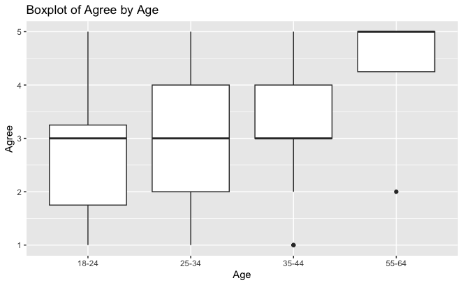

```r
ggplot(data_merged, aes(x = Age, y = Agree)) +
  geom_boxplot() +
  labs(title = "Boxplot of Agree by Age", x = "Age", y = "Agree")
```

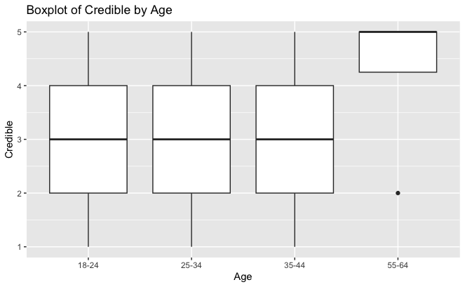

```r
ggplot(data_merged, aes(x = Age, y = Credible)) +
  geom_boxplot() +
  labs(title = "Boxplot of Credible by Age", x = "Age", y = "Credible")
```

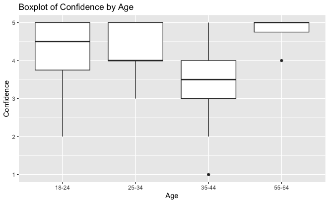

```r
ggplot(data_merged, aes(x = Age, y = Confidence)) +
  geom_boxplot() +
  labs(title = "Boxplot of Confidence by Age", x = "Age", y = "Confidence")
```

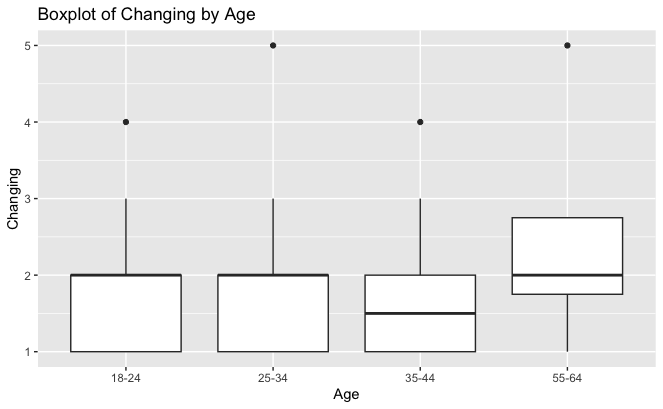

```r
ggplot(data_merged, aes(x = Age, y = Changing)) +
  geom_boxplot() +
  labs(title = "Boxplot of Changing by Age", x = "Age", y = "Changing")
```

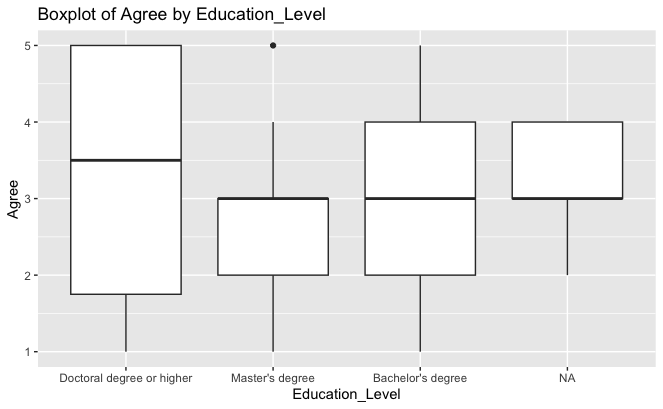

```r
ggplot(data_merged, aes(x = Education_Level, y = Agree)) +
  geom_boxplot() +
  labs(title = "Boxplot of Agree by Education_Level", x = "Education_Level", y = "Agree")
```

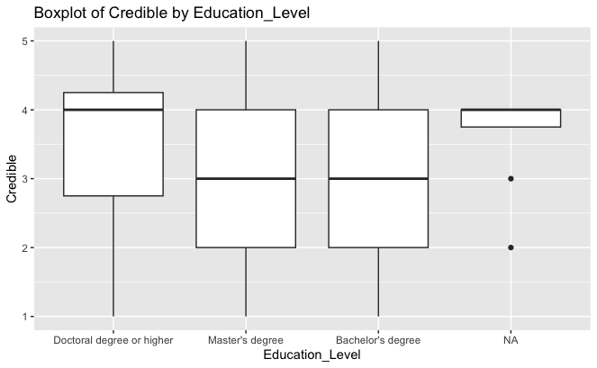

```r
ggplot(data_merged, aes(x = Education_Level, y = Credible)) +
  geom_boxplot() +
  labs(title = "Boxplot of Credible by Education_Level", x = "Education_Level", y = "Credible")
```

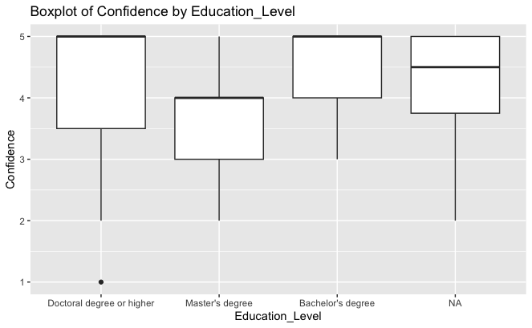

```r
ggplot(data_merged, aes(x = Education_Level, y = Confidence)) +
  geom_boxplot() +
  labs(title = "Boxplot of Confidence by Education_Level", x = "Education_Level", y = "Confidence")
```

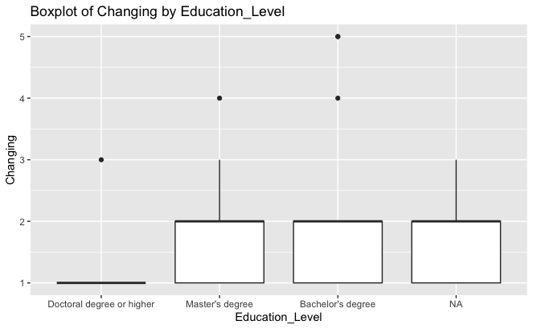

```r
ggplot(data_merged, aes(x = Education_Level, y = Changing)) +
  geom_boxplot() +
  labs(title = "Boxplot of Changing by Education_Level", x = "Education_Level", y = "Changing")
```

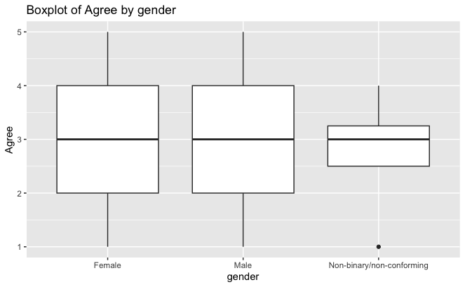

```r
ggplot(data_merged, aes(x = gender, y = Agree)) +
  geom_boxplot() +
  labs(title = "Boxplot of Agree by gender", x = "gender", y = "Agree")
```

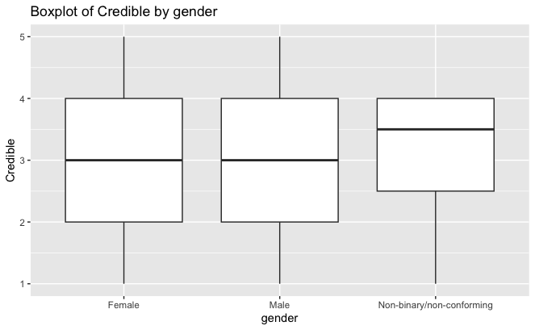

```r
ggplot(data_merged, aes(x = gender, y = Credible)) +
  geom_boxplot() +
  labs(title = "Boxplot of Credible by gender", x = "gender", y = "Credible")
```

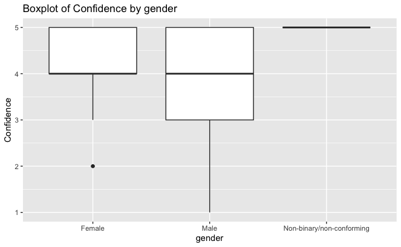

```r
ggplot(data_merged, aes(x = gender, y = Confidence)) +
  geom_boxplot() +
  labs(title = "Boxplot of Confidence by gender", x = "gender", y = "Confidence")
```

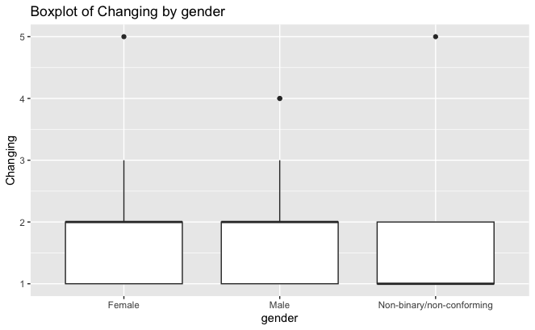

```r
ggplot(data_merged, aes(x = gender, y = Changing)) +
  geom_boxplot() +
  labs(title = "Boxplot of Changing by gender", x = "gender", y = "Changing")
```

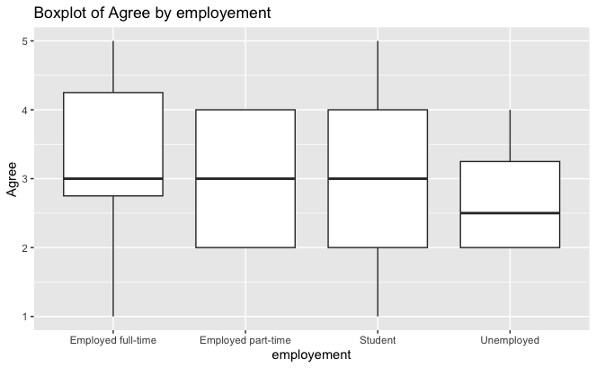

```r
ggplot(data_merged, aes(x = employement, y = Agree)) +
  geom_boxplot() +
  labs(title = "Boxplot of Agree by employement", x = "employement", y = "Agree")
```

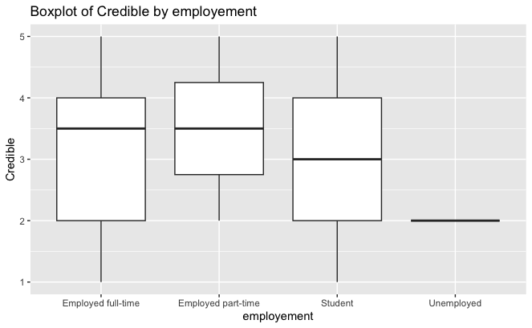

```r
ggplot(data_merged, aes(x = employement, y = Credible)) +
  geom_boxplot() +
  labs(title = "Boxplot of Credible by employement", x = "employement", y = "Credible")
```

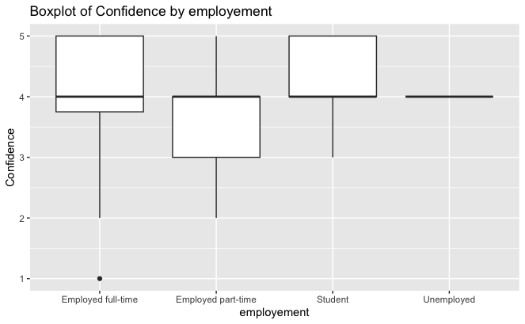

```r
ggplot(data_merged, aes(x = employement, y = Confidence)) +
  geom_boxplot() +
  labs(title = "Boxplot of Confidence by employement", x = "employement", y = "Confidence")
```

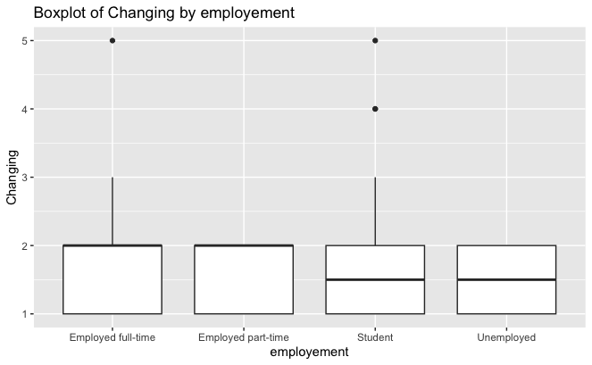

```r
ggplot(data_merged, aes(x = employement, y = Changing)) +
  geom_boxplot() +
  labs(title = "Boxplot of Changing by employement", x = "employement", y = "Changing")
```